# coversim

Christopher Weld ceweld241@gmail.com, Lawrence Leemis leemis@math.wm.edu

2026-03-02

## Introduction

The `coversim` function performs coverage simulations for two-dimensional confidence region plots, and is part of the conf package. It is capable of performing numerous simulation iterations (or replications) in a single command.

Each trial within the `coversim` function uses a random dataset with user-specified parameters (default), or a user specified dataset matrix. Each trial identifies if a point of interest (either the population parameters or a user specified point) is within or outside of the confidence region.

The `coversim` function returns the number of replications completed, replications containing the point of interest within the confidence region, and if any replications resulted in an error. Errors are uncommon but occur when `crplot` is unable to plot the confidence region, typically due challenging confidence region size (when alpha ~ 0) and/or shape (small sample sizes, e.g., two or three samples to estimate a two-parameter univariate probability model).

## Methodology

The `coversim` function calls the `crplot` function (also in the `conf` package) in each of its trials. The `crplot` function plots a confidence region corresponding to the random (default) or user specified dataset (using the optional argument `dataset`). It then leverages the `inpolygon` function from the `pracma` package to determine if the confidence region covers or misses the point of interest (meaning the point is or is not contained within its enclosed area). It prints a summary of the results (replications by total number, covered, and errors) to the console upon completion, with the option to return and store additional data.

## Installation Instructions

The `coversim` function is accessible following installation of the `conf` package:

```
install.packages("conf")
library(conf)
```

## Examples: a single `coversim` trial

The `crplot` function is first shown below before demonstrating the `coversim` function. The confidence region for 10 random variates from a normal$(\mu = 5, \sigma = 10)$ is plot using:

```
#> [1] "90% confidence region plot complete; made using 98 boundary points."
```

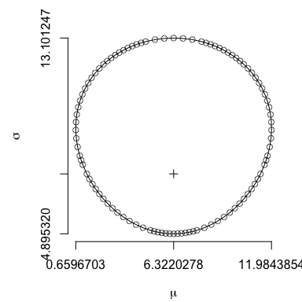

```r
library(conf)
set.seed(1)
crplot(rnorm(10, mean = 5, sd = 10), alpha = 0.1, distn = "norm")
```

Shown next, the `coversim` function both completes a confidence region plot and identifies if its area contains the true population parameters (as its default) in a single command. The population parameters are specified in `coversim` using their Greek alphabet symbol name. Use `?coversim` to view the help page containing probability density functions corresponding to each available distribution in order to ensure proper usage.

```
#> [1] "------------------ 10 samples in each of 1 iterations ---------------------"
#>
#> [1] "...now using alpha: 0.1"
#> 100% complete
#> [1] "1 replications complete."
#> [1] "1 confidence regions contained the true parameters."
#> [1] "0 total errors."
#>
#> [1] "coverage simulation summary (1 replications per parameterization):"
#>      alpha  n coverage errors
#> [1,]   0.1 10        1      0
```

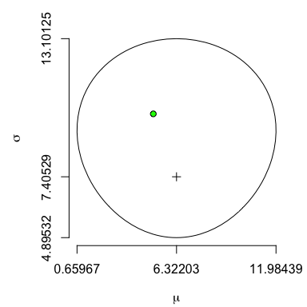

```r
coversim(alpha = 0.1, distn = "norm", n = 10, iter = 1, mu = 5, sigma = 10, showplot = TRUE, seed = 1)
```

Note that an identical confidence region area results in the two preceding plots because the random number stream in both is set using the optional `coversim` argument `seed = 1`. The optional argument `showplot` is also set to `TRUE` so that the resulting confidence region plot is shown. Its plot is augmented with a green point at the population parameters, $(\mu = 5, \sigma = 10)$, indicating it is contained within the confidence region area.

It is also possible to identify coverage (or lack thereof) of a point other than the population parameters using `coversim`. This is done with the optional argument `point`, set to the chosen coordinate. Next, the point $(\mu = 10, \sigma = 6)$ is assessed using the same confidence region. That point just misses coverage within its confidence region area, therefore `coversim` colors both the point and its corresponding confidence region boundary red to indicate missed coverage.

```
#> [1] "------------------ 10 samples in each of 1 iterations ---------------------"
#>
#> [1] "...now using alpha: 0.1"
#> 100% complete
#> [1] "1 replications complete."
#> [1] "0 confidence regions contained the true parameters."
#> [1] "0 total errors."
#>
#> [1] "coverage simulation summary (1 replications per parameterization):"
#>      alpha  n coverage errors
#> [1,]   0.1 10        0      0
```

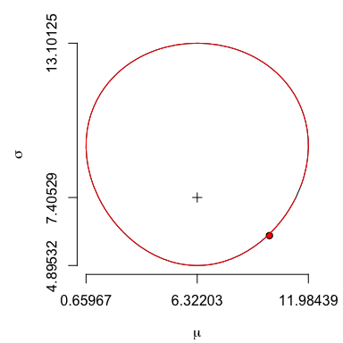

```r
coversim(alpha = 0.1, distn = "norm", n = 10, iter = 1, mu = 5, sigma = 10, showplot = TRUE, seed = 1, point = c(10, 6))
```

## Examples: multiple `coversim` iterations

The `coversim` function can automate and record coverage assessments for numerous trials in a single command. The example below illustrates 10 iterations, each developing a confidence region from 16 random sample values from a gamma$(\theta = 1, \kappa = 2)$ distribution.

```
#> [1] "------------------ 16 samples in each of 10 iterations ---------------------"
#>
#> [1] "...now using alpha: 0.5"
#> 10% complete
#> 20% complete
#> 30% complete
#> 40% complete
#> 50% complete
#> 60% complete
#> 70% complete
#> 80% complete
#> 90% complete
#> 100% complete
#> [1] "10 replications complete."
#> [1] "6 confidence regions contained the true parameters."
#> [1] "0 total errors."
#>
#> [1] "coverage simulation summary (10 replications per parameterization):"
#>      alpha  n coverage errors
#> [1,]   0.5 16      0.6      0
```

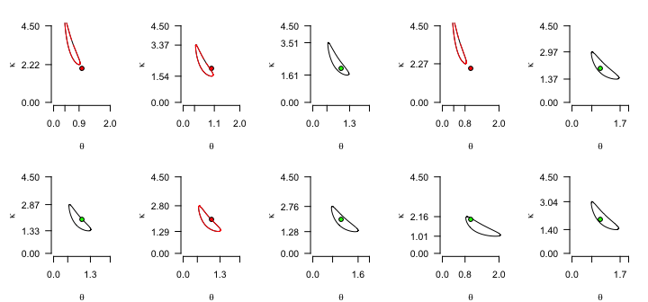

```r
par(mfrow = c(2, 5))
coversim(alpha = 0.5, distn = "gamma", n = 16, iter = 10, theta = 1, kappa = 2, showplot = TRUE, mlelab = FALSE, xlim = c(0, 2), ylim = c(0, 4.5), sf = c(1, 2), ylas = 1)
```

Both the console output and the plots indicate that 6 of 10 iterations produce confidence regions covering the true population parameters, and 4 of 10 iterations result in confidence regions that miss the population parameters. The actual coverage for this simulation is therefore 0.6, whereas its nominal (or stated) coverage is 0.5.

For likelihood-ratio based confidence regions of two-parameter univariate probability models, the nominal coverage is asymptotically exact. For small sample sizes, however, typically a negative bias exists (albeit counter to the aforementioned result attained using only 10 iterations). The next simulation will support this claim.

Simulate a $90\%$ confidence region for $n = \{2, 3, \ldots, 30\}$ random samples from a Weibull$(\kappa = 3, \lambda = 1 / 2)$ population. For each $n$, conduct $10,000$ replications, and report its resulting actual coverage.

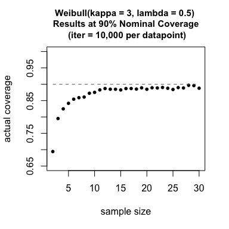

```r
# Note: due to its long runtime, plot results pictured below were imported.  Code producing analogous (but not identical) results is none-the-less given here:
reps <- 10000      # 10,000 iterations per (alpha, n) parameterization
n <- c(2:30)       # sample sizes to assess
coversim(alpha = 0.1, distn = "weibull", n = n, iter = reps, kappa = 3, lambda = 1/2, main = "Weibull(kappa = 3, lambda = 0.5) \n Results at 90% Nominal Coverage \n (iter = 10,000 per datapoint)")
```

Notable separation between the nominal (dotted line) and actual coverages (points) for small $n$ supports the claim of negative bias for confidence region coverage at those respective sample sizes for this particular population probability distribution.

The `coversim` command above provides a summary plot of sample size vs actual coverage because length(n) > length(alpha). When length(n) < length(alpha), summary plot(s) of nominal coverage vs actual coverage result. The next plot demonstrates those circumstances.

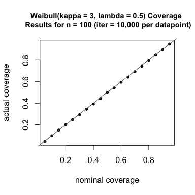

```r
# Note: due to its long runtime, plot results pictured below were imported (patched together from several days of recording).  Code producing analogous (but not identical) results is none-the-less given here:
reps <- 10000         # 10,000 iterations per parameterization
n <- 100              # sample sizes to assess
a <- seq(0.1, 0.9, by = 0.01)   # alpha values to assess
coversim(alpha = a, distn = "weibull", n = n, iter = reps, kappa = 3, lambda = 1/2, main = "Weibull(kappa = 3, lambda = 0.5) Coverage \n Results for n = 100 (iter = 10,000 per datapoint)")
```

This plot demonstrates that $n = 100$ samples result in a confidence region whose actual coverage probability is close to its nominal coverage. This is an intuitive result considering its likelihood-ratio based confidence region is asymptotically chi-square distributed; nominal and actual coverage converge as the sample size increases.

## Custom graphics and analysis using `info = TRUE`

The optional argument `info = TRUE` directs `coversim` to return a list summarizing all simulations. It will print to the console, unless directed via `x <- coversim(..., info = TRUE)` to store in `x` (or whatever name specified). The latter is recommended.

The returned list has the following labels (with accompanying descriptions):

- `alab`: a vector associated with alpha values for the corresponding results
- `nlab`: a vector associated with n values (sample size) for the corresponding results
- `results`: a matrix; rows represent unique (alab, nlab) parameterization, columns represent coverage results per iteration (1 if covered, 0 otherwise)
- `errors`: a matrix; rows represent unique (alab, nlab) parameterization, columns represent iteration error results (1 if error, 0 otherwise)
- `coverage`: a vector associated with (# covered) / (# successfully assessed), where the quantity successfully assessed ignores any iteration with a confidence region plot error

Additional information is returned when the following optional arguments are set to `TRUE`:

- `samples` (returned using the optional argument `returnsamp = TRUE`): a matrix of $n$ rows and `iter` columns containing the random samples used in the last parameterization of the simulation (corresponding to its last parameterization if multiple are used)
- `quantiles` (returned using the optional argument `returnquant = TRUE`): a matrix of $n$ rows and `iter` columns containing the cdf value of corresponding to the random samples (corresponding to its last parameterization if multiple are used)

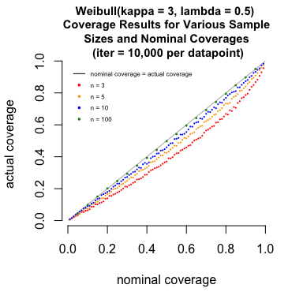

```r
# Note: due to its long runtime, plot results pictured below were imported (patched together from several days of recording).  Code producing analogous (but not identical) results is none-the-less given here:
reps <- 10000                       # 10,000 iterations per parameterization
n1 <- c(3, 5, 10)                   # sample sizes to assess
a1 <- seq(0.99, 0.01, by = -0.01)   # alpha values to assess n = c(3, 5, 10)
a2 <- seq(0.9,  0.1,  by = -0.1)    # alpha values to assess n = 100
x1 <- coversim(alpha = a1, distn = "weibull", n = n1,  iter = reps, kappa = 3, lambda = 1/2, info = TRUE)
x2 <- coversim(alpha = a2, distn = "weibull", n = 100, iter = reps, kappa = 3, lambda = 1/2, info = TRUE)
index3 <- which(x1$nlab == 3)
index5 <- which(x1$nlab == 5)
index10 <- which(x1$nlab == 10)
# make a custom plot with results stored in the lists x1 and x2
par(xpd = TRUE)
plot(1 - x2$alab, x2$coverage, xlim = c(0, 1), ylim = c(0, 1), axes = FALSE, pch = 16, cex = 0.3, col = "forestgreen", xlab = "nominal coverage", ylab = "actual coverage")
title(main = "Weibull(kappa = 3, lambda = 0.5) \n Coverage Results for Various Sample \n Sizes and Nominal Coverages \n (iter = 10,000 per datapoint)", cex.main = 0.92)
points(1-x1$alab[index3], x1$coverage[index3], col = "red", pch = 16, cex = 0.3)    # n = 3
points(1-x1$alab[index5], x1$coverage[index5], col = "orange", pch = 16, cex = 0.3) # n = 5
points(1-x1$alab[index10], x1$coverage[index10], col = "blue", pch = 16, cex = 0.3) # n = 10
lines(c(0, 1), c(0, 1), lty = 1, col = "gray70")
axis(side = 1, at = seq(0, 1, by = 0.2), labels = TRUE)
axis(side = 2, at = seq(0, 1, by = 0.2), labels = TRUE)
legend(0.02, 0.98, legend = rev(c("n = 100", "n = 10", "n = 5", "n = 3", "nominal coverage = actual coverage")), pch = rev(c(16, 16, 16, 16, NA)), col = c("black", "red", "orange", "blue", "forestgreen"), lty = rev(c(NA, NA, NA, NA, 1)), cex = 0.5, y.intersp = 1.5, box.col = NA, bg = NA, pt.lwd = 0.4)
```

Customizing this plot successfully highlights the difference of results between the various parameterizations of the simulation, providing useful intuition how actual coverage varies for small $n$ as a function of the nominal coverage.

## Coverage analysis of user defined datasets

The `coversim` function allows its user to provide their own sample, rather than drawing a random sample from a user-defined parametric population distribution. In those circumstances the user must provide either a vector (for a single iteration) or an `n` by `iter` matrix (for multiple iterations) of samples, and a point of interest to assess coverage relative to.

The next example illustrates a single coverage assessment for a user-defined dataset of ball bearing failure times, given by Lieblein and Zelen[^1], relative to a user-defined the point of interest. Its fit to the Weibull distribution is explained in depth in the Reliability textbook by Leemis[^2]. After storing ball bearing failure times (in millions of revolutions) into the vector `ballbearing`, `coversim` assesses that a $90\%$ confidence region does not cover the point $\kappa = 1, \lambda = 0.015$. The fact this point (with $\kappa = 1$) is not covered supports the intuition that the ball bearings are wearing out, and therefore their times to failure do not follow an exponential distribution.

```
#> [1] "------------------ 23 samples in each of 1 iterations ---------------------"
#>
#> [1] "...now using alpha: 0.1"
#> 100% complete
#> [1] "1 replications complete."
#> [1] "0 confidence regions contained the true parameters."
#> [1] "0 total errors."
#>
#> [1] "coverage simulation summary (1 replications per parameterization):"
#>      alpha  n coverage errors
#> [1,]   0.1 23        0      0
```

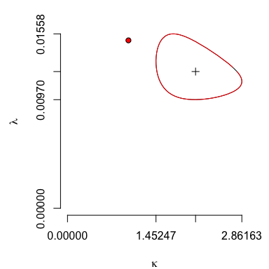

```r
ballbearing <- c(17.88, 28.92, 33.00, 41.52, 42.12, 45.60, 48.48, 51.84,
                 51.96, 54.12, 55.56, 67.80, 68.64, 68.64, 68.88, 84.12,
                 93.12, 98.64, 105.12, 105.84, 127.92, 128.04, 173.40)
coversim(alpha = 0.1, distn = "weibull", dataset = ballbearing, point = c(1, 0.015), showplot = TRUE, origin = TRUE)
```

The `coversim` function `dataset` argument can also accept multiple iterations of user-specified samples in a single command. For those circumstances, `dataset` is an `n` by `iter` matrix of sample values: each row representing one of `n` drawn samples, and each column representing a sample set. This capability is demonstrated next.

Suppose five samples of the aforementioned ball bearing dataset were each collected by four different engineers, and the $90\%$ confidence region of each respective subset is assessed for coverage of the point $\kappa = 1, \lambda = 0.015$. In this case `dataset` is a 5-row, 4-column matrix, with each column representing a sample set corresponding to one of the engineers. Each column of the `dataset` matrix produces a confidence region for the Weibull population parameters, which is subsequently assessed to either cover or miss the $\kappa = 1, \lambda = 0.015$ point of interest.

```
#> [1] "------------------ 5 samples in each of 4 iterations ---------------------"
#>
#> [1] "...now using alpha: 0.1"
#> 25% complete
#> 50% complete
#> 75% complete
#> 100% complete
#> [1] "4 replications complete."
#> [1] "0 confidence regions contained the true parameters."
#> [1] "0 total errors."
#>
#> [1] "coverage simulation summary (4 replications per parameterization):"
#>      alpha n coverage errors
#> [1,]   0.1 5        0      0
```

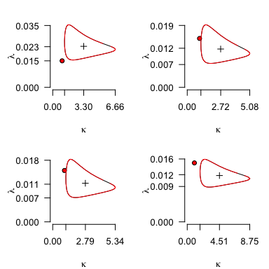

```r
set.seed(1)              # ensure consistent results will illustrate in this vignette
par(mfrow = c(2, 2))     # display resulting plots in a 2 row by 2 column grid
samplematrix <- matrix(sample(ballbearing, 20), ncol = 4)   # subset 20 samples into four groups (columns)
coversim(alpha = 0.1, distn = "weibull", dataset = samplematrix, point = c(1, 0.015),
         sf = c(2, 3), ylas = 1, showplot = TRUE, origin = TRUE)
```

[^1]: Lieblein, J., and Zelen, M. (1956), Statistical Investigation of the Fatigue Life of Deep-Groove Ball Bearings, *Journal of Research of the National Bureau of Standards*, 57, 273–316
[^2]: Leemis, L. (1995), *Reliability: Probabilistic Models and Statistical Methods*, Prentice-Hall Inc., 345–251